# Régression linéaire

Lier deux variables entre elles

Sys.Date()

## Qu’est ce qu’une régression linéaire ?

C’est une modélisation statistique (une équation) qui cherche à relier de façon linéaire une variable dite expliquée, à une ou plusieurs autres variables, dites explicatives.

La régression linéaire simple avec une seule variable explicative c’est :  
`y = a.x + b + e`  
y est la variable expliquée (dépendante), que nous souhaitons décrire et prédire. Souvent représentée sur l’axe des ordonnées.  
x est la variable explicative (indépendante), permettant de décrire et prédire y, souvent représentée sur l’axe des abscisses.  
b est l’ordonnée à l’origine.  
e est l’erreur

## A quoi ça sert ?

Comprendre la relation entre la variable expliquée et la (ou les) variables explicatives.  
Prédire à partir de la variable explicative (prédictive dans ce cas là) quelle sera la valeur possible de la variable expliquée.

## En pratique ça donne quoi ?

Il ne faut pas oublier la question que l’on se pose : Dans une regression l’hypothèse nulle H0 est que la variable explicative ne permet pas d’expliquer la variable explicative.

Importer les données (à télécharger ici donnees.csv ) et les manipuler pour avoir le tableau qui nous intéresse.

```r
library(dplyr)
library(tidyr)
```

```r
#on importe les données
donnees<-read.csv2('donnees.csv',header=TRUE,sep=';')

#Selectionner la variable expliquée et la (ou les) variables explicatives
names(donnees)
```

```
##  [1] "CLEOBS"                       "OT"
##  [3] "TAILLE"                       "PROF"
##  [5] "ESP"                          "DATEDEBUT"
##  [7] "DATEFIN"                      "DATEDETERMINATIONOBS"
##  [9] "X"                            "Y"
## [11] "PRECISION"                    "ORGANISMEOBSERVATEUR"
## [13] "ORGANISMEGESTIONNAIREDONNEES"
```

```r
donnees_filt<-donnees %>%
 dplyr::select(TAILLE, PROF)

#supprimer les lignes avec valeurs manquantes, fonction drop_na du package 'tidyr'
donnees_na <- donnees_filt %>% drop_na(TAILLE, PROF)
```

On regarde un peu ce qu’on a.

```r
summary(donnees_na)
```

```
##     TAILLE              PROF
##  Length:26          Length:26
##  Class :character   Class :character
##  Mode  :character   Mode  :character
```

La profondeur en class character peut être source de problème. On le veut en numérique.

```r
donnees_na$PROF<-as.numeric(donnees_na$PROF)
donnees_na$TAILLE<-as.numeric(donnees_na$TAILLE)

class(donnees_na$PROF)
```

```
## [1] "numeric"
```

On produit notre modèle de régression linéaire entre la profondeur et la taille des poissons de notre échantillon et on visualise le résultat.

```r
#régression linéaire avec fonction lm (?lm pour l'aide R)
mod<-lm(TAILLE~PROF, donnees_na)
#visualiser les données
plot(donnees_na$PROF, donnees_na$TAILLE)
abline(mod)
title("Régression linéaire")
summary(mod)
```

```
##
## Call:
## lm(formula = TAILLE ~ PROF, data = donnees_na)
##
## Residuals:
##     Min      1Q  Median      3Q     Max
## -10.045  -3.511  -1.040   4.415  11.135
##
## Coefficients:
##             Estimate Std. Error t value Pr(>|t|)
## (Intercept)  -2.0334     2.5199  -0.807    0.428
## PROF          1.0599     0.1272   8.331 1.53e-08 ***
## ---
## Signif. codes:  0 '***' 0.001 '**' 0.01 '*' 0.05 '.' 0.1 ' ' 1
##
## Residual standard error: 5.761 on 24 degrees of freedom
## Multiple R-squared:  0.743,  Adjusted R-squared:  0.7323
## F-statistic:  69.4 on 1 and 24 DF,  p-value: 1.53e-08
```

```r
#visualiser les résidus, étant la distance des points par rapport au modèle
segments(donnees_na$PROF,fitted(mod),donnees_na$PROF, donnees_na$TAILLE)
#frame valeurs taille
min(donnees_na$PROF)
```

```
## [1] 5
```

```r
max(donnees_na$PROF)
```

```
## [1] 40
```

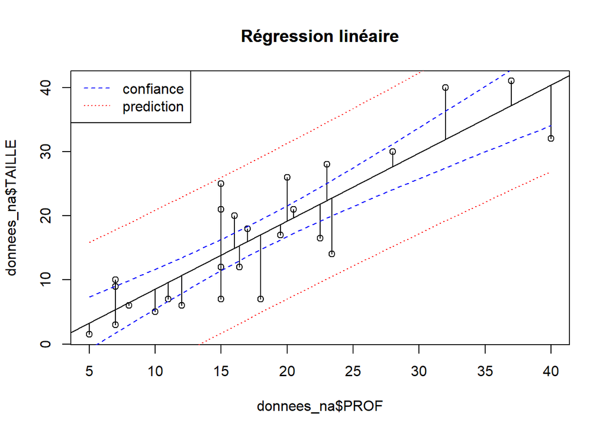

```r
pred.frame<-data.frame(PROF= 5:40)
#predict permet des predictions d'après les résultats du modèle
pc<-predict(mod, interval="confidence", newdata=pred.frame)
pp<-predict(mod, interval="prediction", newdata=pred.frame)
#valeur des intervalles de confiance haut et bas [,2:3]. lty le type de ligne tracés
matlines(pred.frame, pc[,2:3], lty=c(2,2), col="blue")
matlines(pred.frame, pp[,2:3], lty=c(3,3), col="red")
#légende des matlines
legend("topleft",c("confiance","prediction"),lty=c(2,3), col=c("blue","red"))
title("Régression linéaire")
```

Regardons les résultats de la régression de plus près.

```r
summary(mod)
```

```
##
## Call:
## lm(formula = TAILLE ~ PROF, data = donnees_na)
##
## Residuals:
##     Min      1Q  Median      3Q     Max
## -10.045  -3.511  -1.040   4.415  11.135
##
## Coefficients:
##             Estimate Std. Error t value Pr(>|t|)
## (Intercept)  -2.0334     2.5199  -0.807    0.428
## PROF          1.0599     0.1272   8.331 1.53e-08 ***
## ---
## Signif. codes:  0 '***' 0.001 '**' 0.01 '*' 0.05 '.' 0.1 ' ' 1
##
## Residual standard error: 5.761 on 24 degrees of freedom
## Multiple R-squared:  0.743,  Adjusted R-squared:  0.7323
## F-statistic:  69.4 on 1 and 24 DF,  p-value: 1.53e-08
```

Le calcul du **coefficient de corrélation** peut aussi se faire avec la fonction `cor`

```r
cor(donnees_na$PROF, donnees_na$TAILLE)
```

```
## [1] 0.8619939
```

Si R = 0, il n’y a pas de relation linéaire entre les variables, si R = 1 la relation linéaire est parfaite, tous les points sont sur la droite.

Les variables PROF et TAILLE semblent reliées étant donné la correlation entre ces variables, le coefficient de la pente et la p-value. Etant donné le R² la profondeur a un fort impact sur la taille mais il reste cependant une partie inexpliquée.

## Valider le modèle en testant les hypothèses sur lequel il repose

La régression linéaire repose sur des hypothèses: normalité, linearité, homoscedasticité, and absence of multicollinearity

**Normalité**

Afin de faire des inférences valides issu de ce modèle (pour vérifier les prédictions basées sur cette droite), il faut tester la normalité des erreurs résiduels. Les valeurs résiduels doivent suivre une distribution normale pour que le modèle soit robuste.

Plusieurs manière de tester cela:

Un histograme pour visualiser si la distribution suit une loi normale

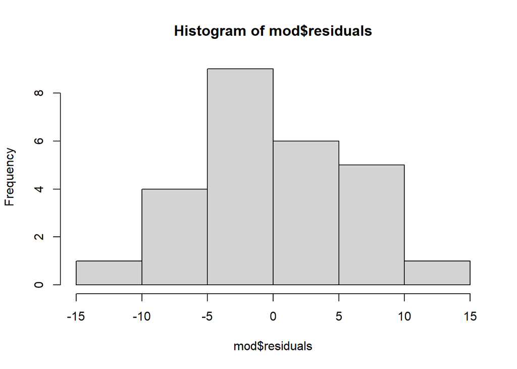

```r
hist(mod$residuals)
```

Un qqplot(quantile-quantile) comparant la distribution des résidus à une distribution normale

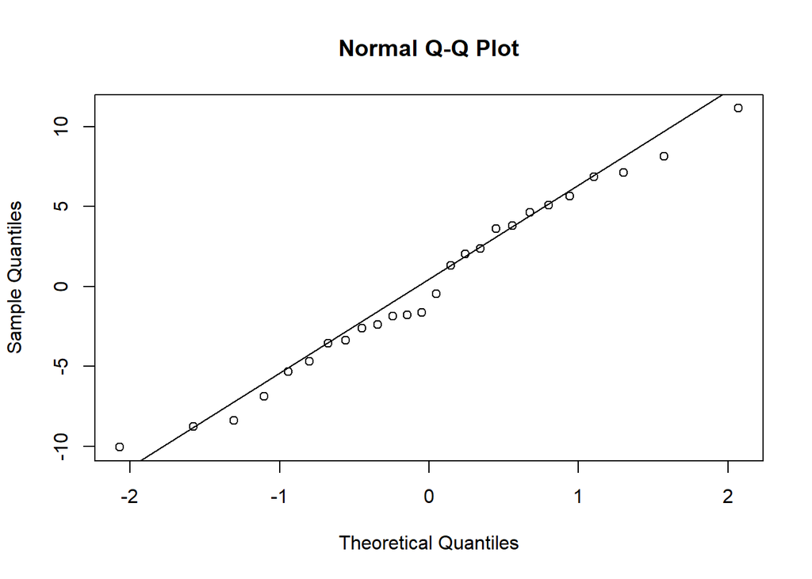

```r
qqnorm(mod$residuals)
qqline(mod$residuals)
```

Ces deux graphiques semblent indiqués une loi normale.

Un shapiro test dont l’hypothèse H0 est que l’échantillon suit une loi normale

```r
shapiro.test(mod$residuals)
```

```
##
##  Shapiro-Wilk normality test
##
## data:  mod$residuals
## W = 0.97797, p-value = 0.8282
```

La p-value est supérieur à 0.05, on ne peut PAS dire que les résidus ne suivent PAS une loi normale.

L’erreur résiduel semble bien suivre une loi normale.

**L’homoscédasticité** C’est quand la dispersion est homogène, l’ensemble des erreurs à une variance similaire.

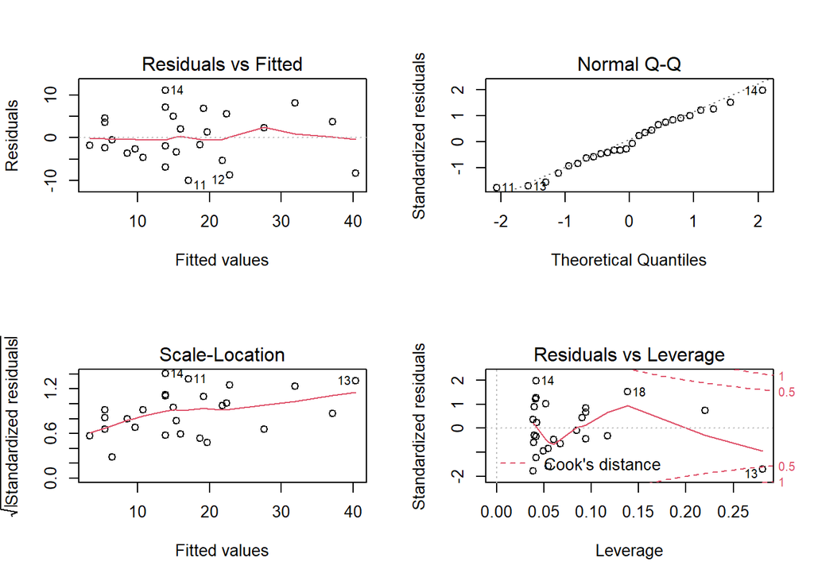

```r
par(mfrow=c(2,2))
plot(mod)
```

Plus la ligne rouge est proche de zéro plus il y a de l’homoscédasticité. Plus elle s’en sépare plus il y a de l’hétéroscédasticité. On peut le tester statistiquement avec le test de Breusch Pagan et le ncvTest.

```r
library(lmtest)
library(car)
```

```r
lmtest::bptest(mod)
```

```
##
##  studentized Breusch-Pagan test
##
## data:  mod
## BP = 2.4749, df = 1, p-value = 0.1157
```

```r
car::ncvTest(mod)
```

```
## Non-constant Variance Score Test
## Variance formula: ~ fitted.values
## Chisquare = 1.396593, Df = 1, p = 0.23729
```

**Linéarité** Les variables ont une relation linéaire. Lorsque la normalité et l’homoscédasticité sont attestés, il n’y a pas a s’inquiété pour ça.

**Multicollinearité** C’est lorsque des variables explicatives sont très corrélés les unes aux autres, cela peut fausser les résultats. Il faut donc vérifier les coefficients de corrélation, voir si certaines dépassent 0.80, et vérifier le VIF. Nul besoin de s’en inquiéter ici nous n’avons qu’une seule variable explicative (indépendante).